# Exploring Vital Health Factors in Heart Disease Risk Assessment

Author

Bhavani Priya

## Description

The Heart Disease UCI dataset comprises 303 observations and 14 attributes (including the target variable). Each observation represents a patient, and the attributes provide information about the patient’s demographic, clinical, and diagnostic features.

Understanding the role of age and key health factors, such as cholesterol levels, blood sugar levels, and resting blood pressure, in influencing the risk of heart disease is crucial for effective prevention and management strategies.

## Research Question

To what extent do age, gender and key health factors, such as cholesterol levels, blood sugar levels, and resting blood pressure, individually contribute to the risk of heart disease?

Does gender, age and the maximum heart rate achieved play a significant role in the occurrence of heart disease?

**Literature Review:**

Heart disease is a leading cause of morbidity and mortality worldwide, with age and health factors playing pivotal roles in its development and progression. Advancing age is a non-modifiable risk factor associated with increased susceptibility to cardiovascular events (D’Agostino et al., 2008; Lloyd-Jones et al., 2006). Additionally, health factors such as elevated cholesterol levels, high blood pressure, diabetes, obesity, physical inactivity, and smoking are implicated in heart disease pathogenesis (Yusuf et al., 2004). Gender disparities in heart disease prevalence, presentation, and outcomes have been documented, highlighting the need for gender-sensitive approaches to risk assessment and diagnosis (Hemingway & Marmot, 1999). Interestingly, maximum heart rate achieved during exercise has emerged as a physiological factor influencing heart disease risk, with gender-specific associations observed (Gupta et al., 2020). Understanding the complex interplay between these factors is essential for advancing heart disease research and improving preventive and therapeutic interventions.

## Hypothesis

**Hypothesis for Research Question 1:**

Higher blood sugar levels increase the risk of heart disease, while controlling for age and gender.

Elevated cholesterol levels significantly impact the risk of heart disease, while controlling for age and gender.

Elevated blood pressure levels have a significant effect on the risk of heart disease, while controlling for age and gender.

**Hypothesis for Research Question 2:**

Maximum heart rate achieved during exercise have significant association with the occurrence of heart disease, while controlling for age and gender

## Descriptive Statistics:

**Attributes**:

- Age: The age of the patient in years.
- Sex: The gender of the patient (1 = male; 0 = female).
- Chest Pain Type (CP): The type of chest pain experienced by the patient (1 = atypical angina, 2 = non-anginal pain, 3 = asymptomatic).
- Resting Blood Pressure (Trestbps): The resting blood pressure of the patient in mm Hg.
- Cholesterol (Chol): The serum cholesterol level of the patient in mg/dl.
- Fasting Blood Sugar (Fbs): The fasting blood sugar level of the patient (>120 mg/dl signifies high blood sugar).
- Resting Electrocardiographic Results (Restecg): The resting electrocardiographic results of the patient (0 = normal, 1 = having ST-T wave abnormality, 2 = showing probable or definite left ventricular hypertrophy).
- Maximum Heart Rate Achieved (Thalach): The maximum heart rate achieved by the patient during exercise.
- Exercise-Induced Angina (Exang):Whether the patient experienced exercise-induced angina (1 = yes; 0 = no).
- ST Depression Induced by Exercise Relative to Rest (Oldpeak): The ST depression induced by exercise relative to rest.
- Slope of the Peak Exercise ST Segment (Slope): The slope of the peak exercise ST segment
- Number of Major Vessels (ca): The number of major vessels (0-3) colored by fluoroscopy.
- Thalassemia (Thal):A categorical variable indicating thalassemia type (1 = one gene deletion; 2 = two gene deletion; 3 = three gene deletion).
- Target (Heart Disease): The presence of heart disease in the patient (0 = no heart disease; 1 = heart disease present).

**Libraries**

**Loading Dataset**

```
[1] 303  14
```

```
  age sex cp trestbps chol fbs restecg thalach exang oldpeak slope ca thal
1  63   1  3      145  233   1       0     150     0     2.3     0  0    1
2  37   1  2      130  250   0       1     187     0     3.5     0  0    2
3  41   0  1      130  204   0       0     172     0     1.4     2  0    2
4  56   1  1      120  236   0       1     178     0     0.8     2  0    2
5  57   0  0      120  354   0       1     163     1     0.6     2  0    2
6  57   1  0      140  192   0       1     148     0     0.4     1  0    1
  target
1      1
2      1
3      1
4      1
5      1
6      1
```

```
         vars   n   mean    sd median trimmed   mad min   max range  skew
age         1 303  54.37  9.08   55.0   54.54 10.38  29  77.0  48.0 -0.20
sex         2 303   0.68  0.47    1.0    0.73  0.00   0   1.0   1.0 -0.78
cp          3 303   0.97  1.03    1.0    0.86  1.48   0   3.0   3.0  0.48
trestbps    4 303 131.62 17.54  130.0  130.44 14.83  94 200.0 106.0  0.71
chol        5 303 246.26 51.83  240.0  243.49 47.44 126 564.0 438.0  1.13
fbs         6 303   0.15  0.36    0.0    0.06  0.00   0   1.0   1.0  1.97
restecg     7 303   0.53  0.53    1.0    0.52  0.00   0   2.0   2.0  0.16
thalach     8 303 149.65 22.91  153.0  150.98 22.24  71 202.0 131.0 -0.53
exang       9 303   0.33  0.47    0.0    0.28  0.00   0   1.0   1.0  0.74
oldpeak    10 303   1.04  1.16    0.8    0.86  1.19   0   6.2   6.2  1.26
slope      11 303   1.40  0.62    1.0    1.46  1.48   0   2.0   2.0 -0.50
ca         12 303   0.73  1.02    0.0    0.54  0.00   0   4.0   4.0  1.30
thal       13 303   2.31  0.61    2.0    2.36  0.00   0   3.0   3.0 -0.47
target     14 303   0.54  0.50    1.0    0.56  0.00   0   1.0   1.0 -0.18
         kurtosis   se
age         -0.57 0.52
sex         -1.39 0.03
cp          -1.21 0.06
trestbps     0.87 1.01
chol         4.36 2.98
fbs          1.88 0.02
restecg     -1.37 0.03
thalach     -0.10 1.32
exang       -1.46 0.03
oldpeak      1.50 0.07
slope       -0.65 0.04
ca           0.78 0.06
thal         0.25 0.04
target      -1.97 0.03
```

**Check for missing value**

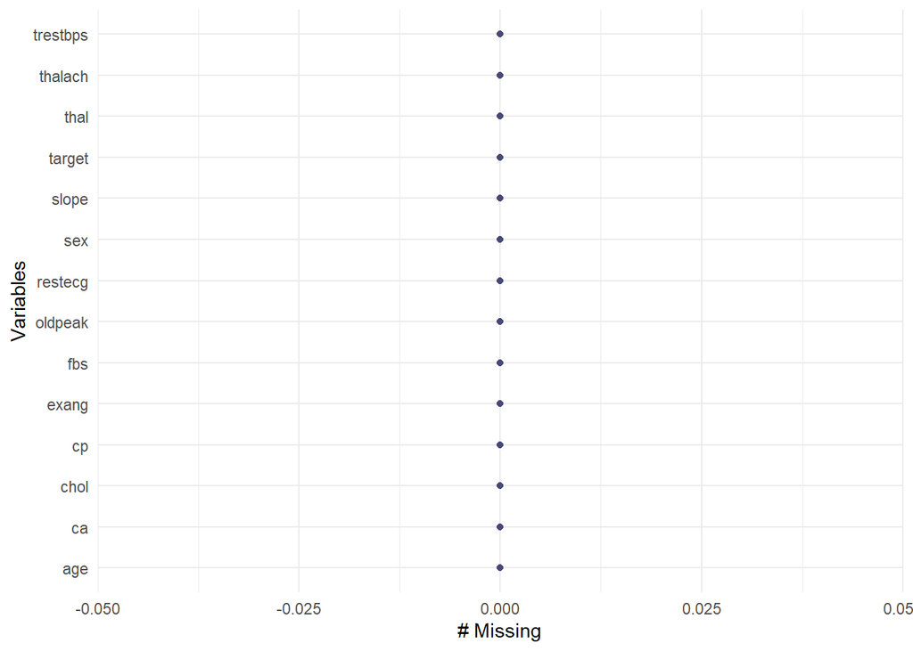

### Factoring Columns:

**Summary of New data**

```r
#summary of new data

setwd("C:/Users/priya/OneDrive/Documents/DACSS_603/Dacss_603")

dfSummary(heart_data_new, plain.ascii = FALSE,
          style = "grid",
          graph.magnif = 0.85,
          varnumbers = FALSE,
          valid.col    = FALSE,
          tmp.img.dir = './tmp')
```

```
temporary images written to 'C:\Users\priya\OneDrive\Documents\DACSS_603\Dacss_603\tmp'
```

### Data Frame Summary

#### heart_data_new

**Dimensions:** 303 x 14  
**Duplicates:** 1

| Variable | Stats / Values | Freqs (% of Valid) | Graph | Missing |
| --- | --- | --- | --- | --- |
| age [integer] | Mean (sd) : 54.4 (9.1) min < med < max: 29 < 55 < 77 IQR (CV) : 13.5 (0.2) | 41 distinct values |  | 0 (0.0%) |
| sex [factor] | 1. Female 2. Male | 96 (31.7%) 207 (68.3%) |  | 0 (0.0%) |
| chest_paintype [factor] | 1. Typical Angina 2. Atypical Angina 3. Non-anginal pain 4. Asymptomatic | 143 (47.2%) 50 (16.5%) 87 (28.7%) 23 ( 7.6%) |  | 0 (0.0%) |
| resting_BP [integer] | Mean (sd) : 131.6 (17.5) min < med < max: 94 < 130 < 200 IQR (CV) : 20 (0.1) | 49 distinct values |  | 0 (0.0%) |
| cholestrol [integer] | Mean (sd) : 246.3 (51.8) min < med < max: 126 < 240 < 564 IQR (CV) : 63.5 (0.2) | 152 distinct values |  | 0 (0.0%) |
| fasting_blood_sugar [factor] | 1. <=120mg/dL 2. >120mg/dL | 258 (85.1%) 45 (14.9%) |  | 0 (0.0%) |
| restecg [factor] | 1. Normal 2. Abnormality 3. Probable or Definite | 147 (48.5%) 152 (50.2%) 4 ( 1.3%) |  | 0 (0.0%) |
| max_heart_rate [integer] | Mean (sd) : 149.6 (22.9) min < med < max: 71 < 153 < 202 IQR (CV) : 32.5 (0.2) | 91 distinct values |  | 0 (0.0%) |
| exercise_induced_angina [factor] | 1. No 2. Yes | 204 (67.3%) 99 (32.7%) |  | 0 (0.0%) |
| oldpeak [numeric] | Mean (sd) : 1 (1.2) min < med < max: 0 < 0.8 < 6.2 IQR (CV) : 1.6 (1.1) | 40 distinct values |  | 0 (0.0%) |
| slope [factor] | 1. 0 2. 1 3. 2 | 21 ( 6.9%) 140 (46.2%) 142 (46.9%) |  | 0 (0.0%) |
| major_vessels [factor] | 1. 0 2. 1 3. 2 4. 3 5. 4 | 175 (57.8%) 65 (21.5%) 38 (12.5%) 20 ( 6.6%) 5 ( 1.7%) |  | 0 (0.0%) |
| thalassamia [factor] | 1. One gene deletion 2. Two gene deletion 3. Three gene deletion | 18 ( 6.0%) 166 (55.1%) 117 (38.9%) |  | 2 (0.7%) |
| heart_disease [factor] | 1. No 2. Yes | 138 (45.5%) 165 (54.5%) |  | 0 (0.0%) |

### Visualization

**Let’s check the distribution of interested variables**

**Age Distribution**

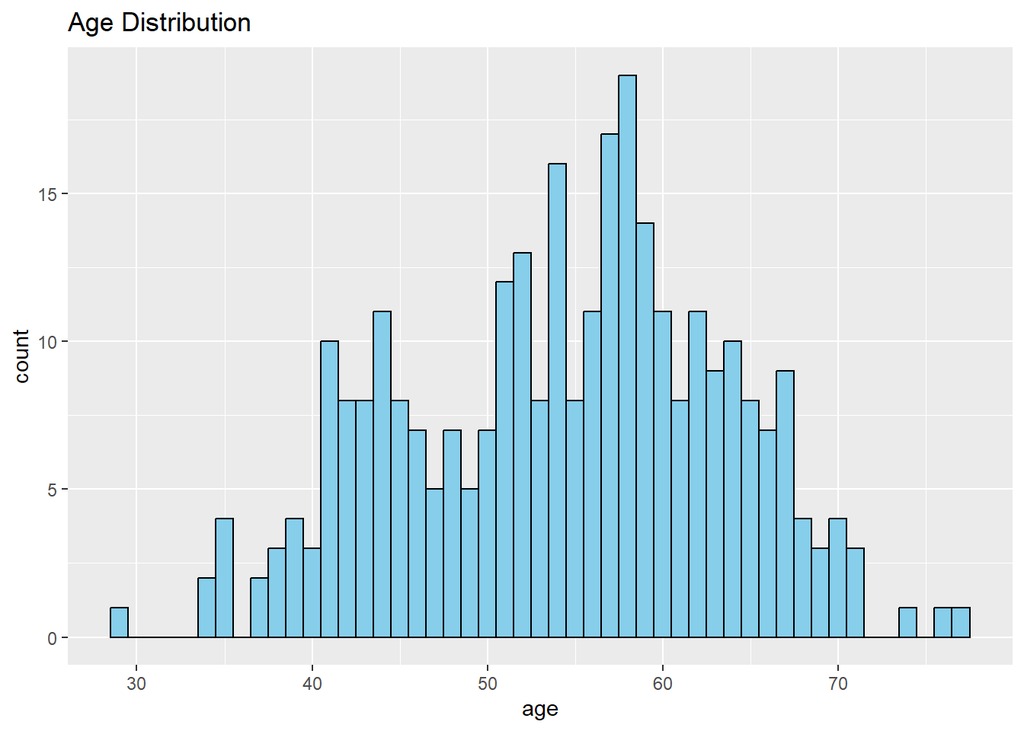

**Distribution of Age Groups**

- This bar chart breaks down the dataset into discrete age groups, providing a clearer view of the age composition of the patient population.
- The vast majority of patients are in the 46-65 age group, indicating a higher prevalence of patients within this middle-age bracket.

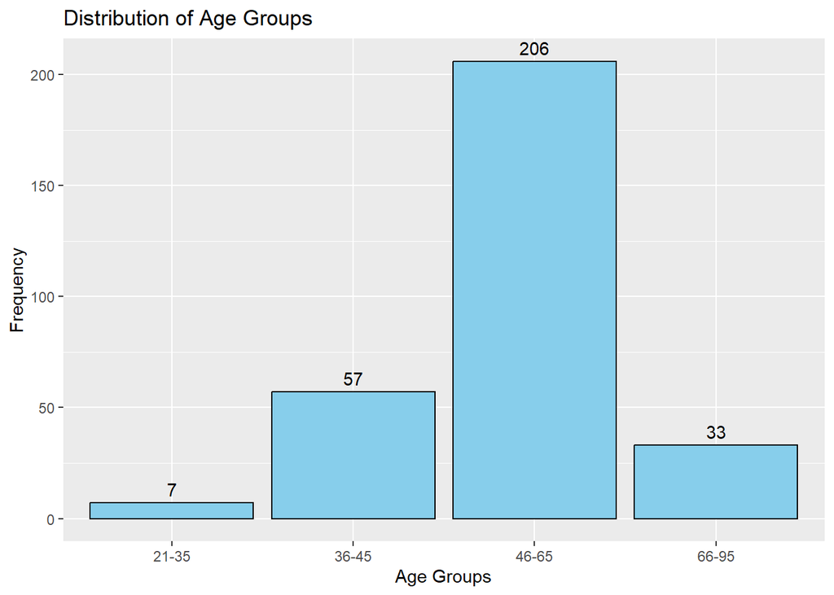

**Distribution of Male and Female**

- The bar chart displays the gender distribution within the dataset, comparing the number of male and female patients.
- Males significantly outnumber females, which could be indicative of either a higher prevalence of heart disease or a sample bias in the collected data.

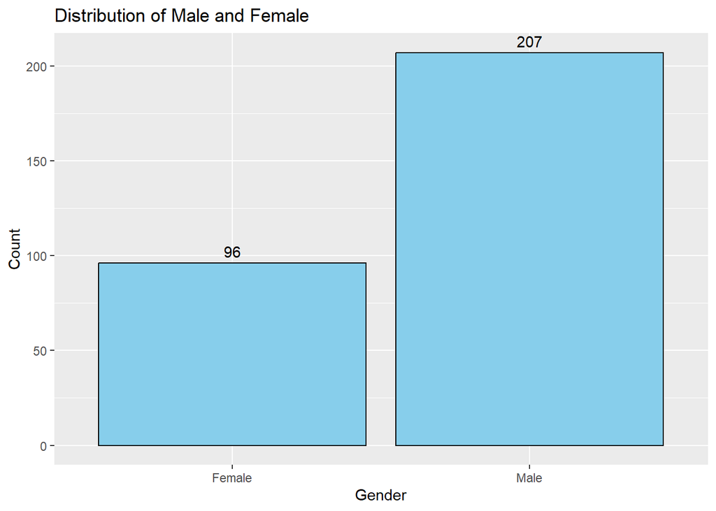

**Analysis of Presence and Absence of Heart Disease**

- This bar chart compares the number of patients with and without heart disease, illustrating the prevalence of the condition within the study population.
- The patients with heart disease slightly outnumber those without, indicating that the dataset may be focused on a high-risk population.

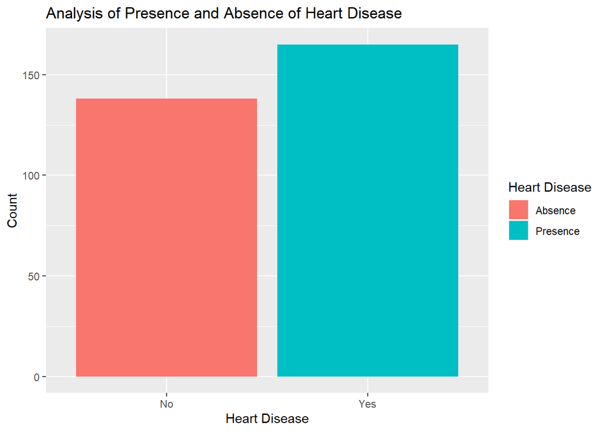

**Cholesterol Levels across Age by Gender**

- This scatter plot presents the relationship between patients’ age and cholesterol levels, separated by gender.
- While there is a wide range of cholesterol levels across all ages, there’s no clear trend indicating an increase or decrease with age, and both genders show considerable overlap in cholesterol levels.

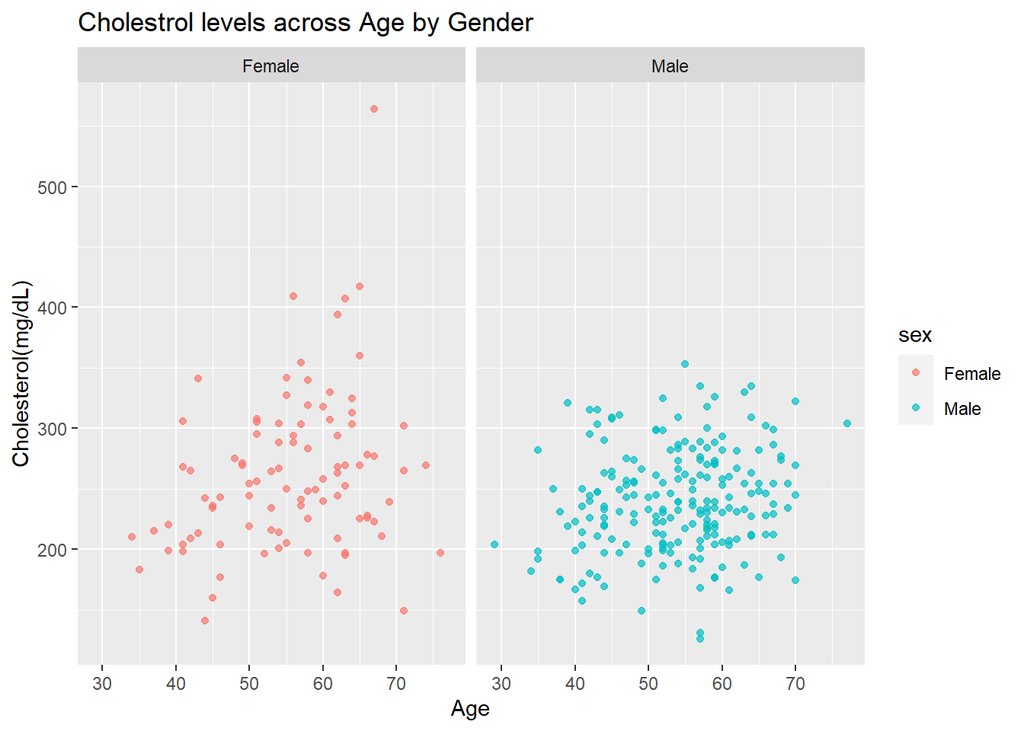

**Relationship between Age & Heart Disease**

- The density plot overlays the age distribution of patients with and without heart disease, allowing for a comparison between the two groups.
- The distribution suggests that occurence of heart disease is almost equally distributed in all ages seeing a peak in age 50-60 and then declining. On the other hand, it is interesting to see most number of people of the ages 55-70 does not have heart disease.

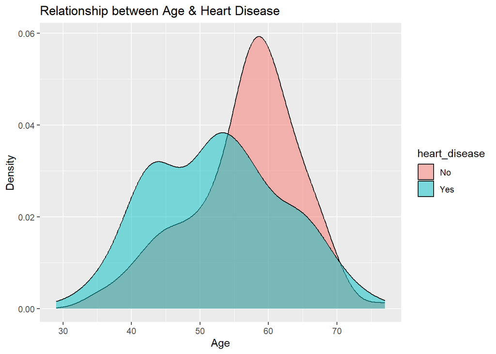

**Resting Blood Pressure by Heart Disease Status and Sex**

- This box plot illustrates the distribution of resting blood pressure among patients, categorized by their heart disease status and gender.
- Both males and females show a similar range of blood pressure values, but there appears to be a slight increase in blood pressure among female patients with no heart disease.

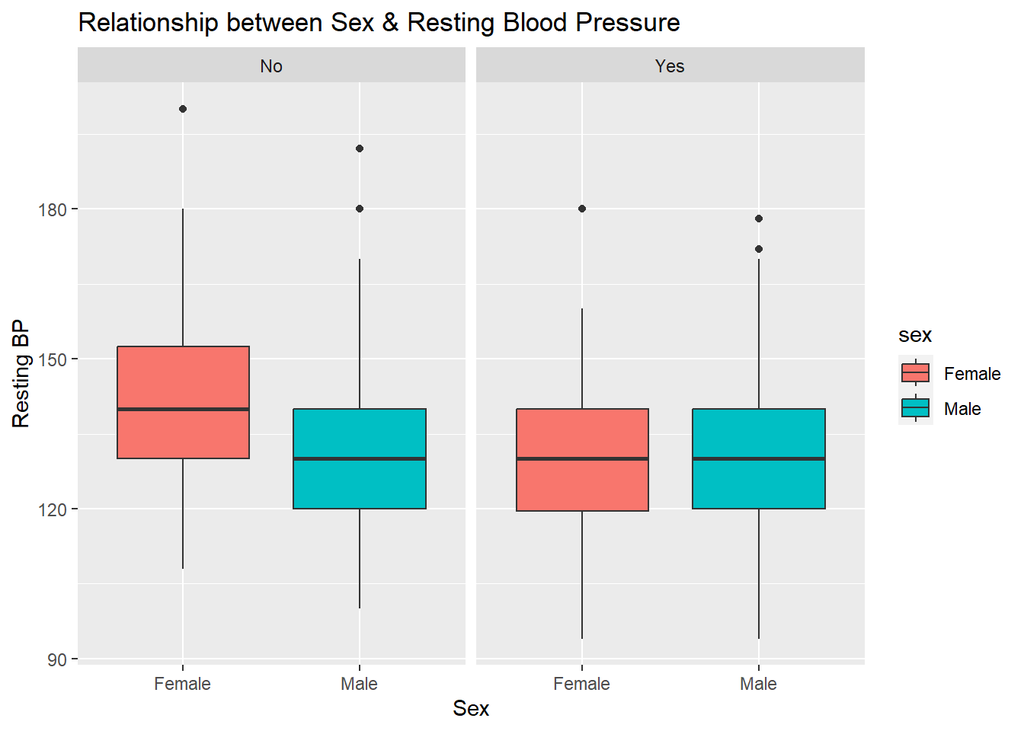

**Relationship between Sex & Max Heart Rate**

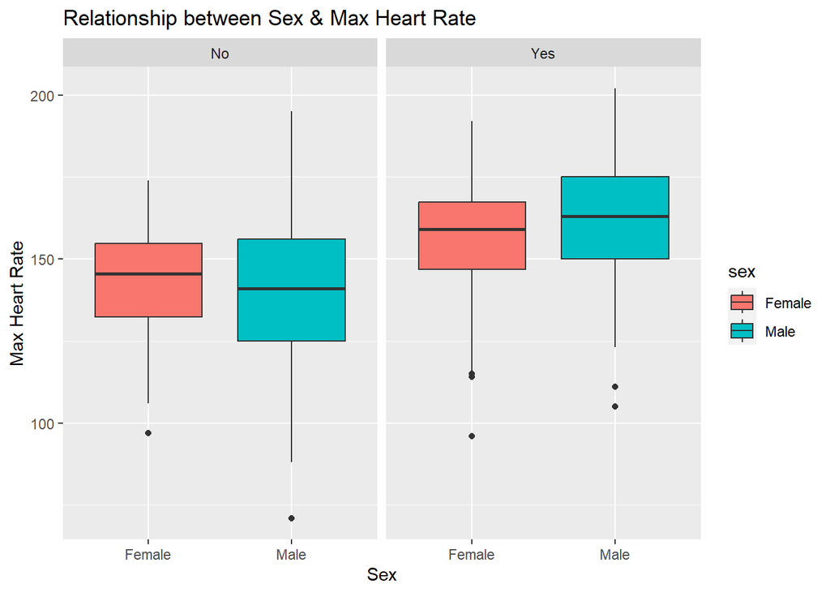

## Hypothesis Testing

- The response variable is - heart_disease(target)
- The explanatory variables are - (resting_bp(trestbps), cholestrol(chol), fasting_blood_sugar(fbs)), max_heart_rate(thalach)
- Control variables - age, gender

### Correlation Plot

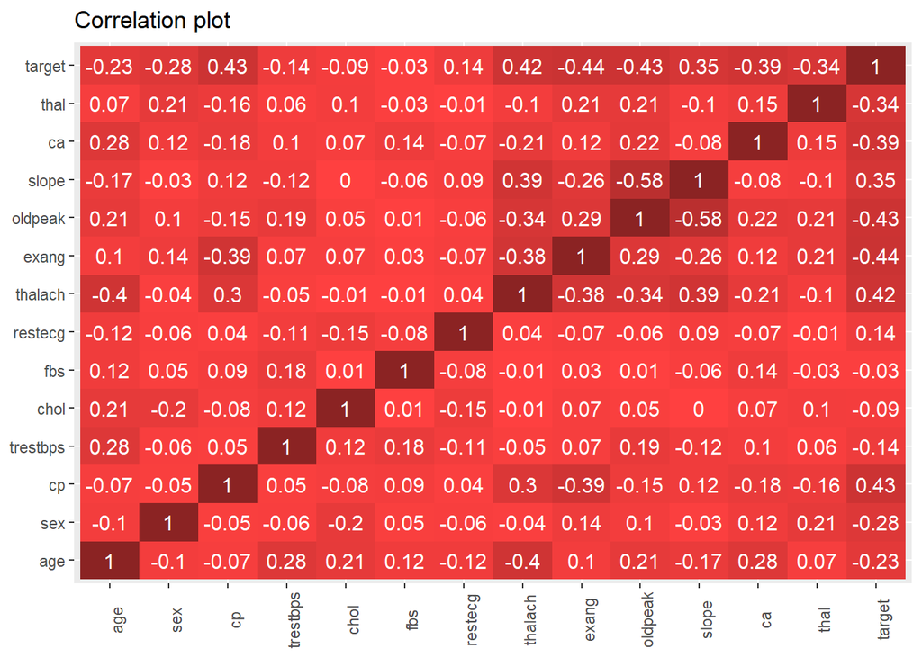

#### Recoding response variable for Logistic Regression

**Function for Adjusted R-square**

### Hypothesis 1.1

**Fasting Blood Sugar and Heart Disease**

```
Call:
glm(formula = heart_disease_binary ~ fasting_bs_binary, family = binomial(link = "logit"),
    data = heart_data_new)

Coefficients:
                  Estimate Std. Error z value Pr(>|z|)
(Intercept)         0.2022     0.1252   1.616    0.106
fasting_bs_binary  -0.1578     0.3234  -0.488    0.626

(Dispersion parameter for binomial family taken to be 1)

    Null deviance: 417.64  on 302  degrees of freedom
Residual deviance: 417.40  on 301  degrees of freedom
AIC: 421.4

Number of Fisher Scoring iterations: 3
```

```
[1] "Adjusted R-Squared"
```

```
[1] 0.9992103
```

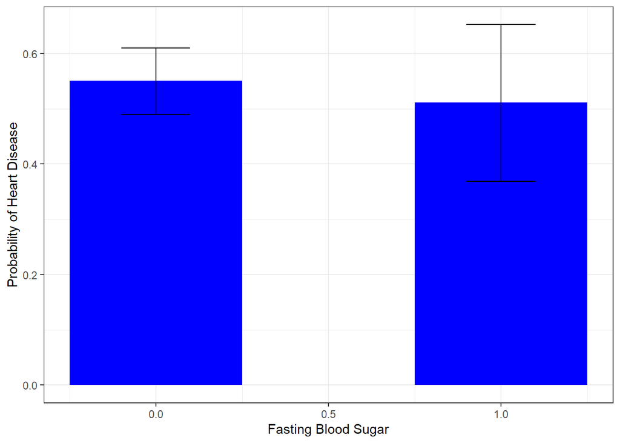

- The intercept suggests a log-odds of 0.2022 for heart disease when fasting blood sugar is zero. But this is not statistically significant at 0.05 level(p=0.106)
- For each unit increase in fasting blood sugar (from absence to presence), the log-odds of heart disease decrease by 0.1578. However, this decrease is not statistically significant at the 0.05 level (p = 0.626).

**With age and sex as control variables**

```
Call:
glm(formula = heart_disease_binary ~ fasting_bs_binary + age +
    sex_binary, family = binomial(link = "logit"), data = heart_data_new)

Coefficients:
                  Estimate Std. Error z value Pr(>|z|)
(Intercept)        4.91168    0.90151   5.448 5.09e-08 ***
fasting_bs_binary  0.10818    0.34793   0.311    0.756
age               -0.06704    0.01494  -4.487 7.22e-06 ***
sex_binary        -1.54303    0.29363  -5.255 1.48e-07 ***
---
Signif. codes:  0 '***' 0.001 '**' 0.01 '*' 0.05 '.' 0.1 ' ' 1

(Dispersion parameter for binomial family taken to be 1)

    Null deviance: 417.64  on 302  degrees of freedom
Residual deviance: 370.48  on 299  degrees of freedom
AIC: 378.48

Number of Fisher Scoring iterations: 4
```

```
[1] "Adjusted R-Squared"
```

```
[1] 0.8422721
```

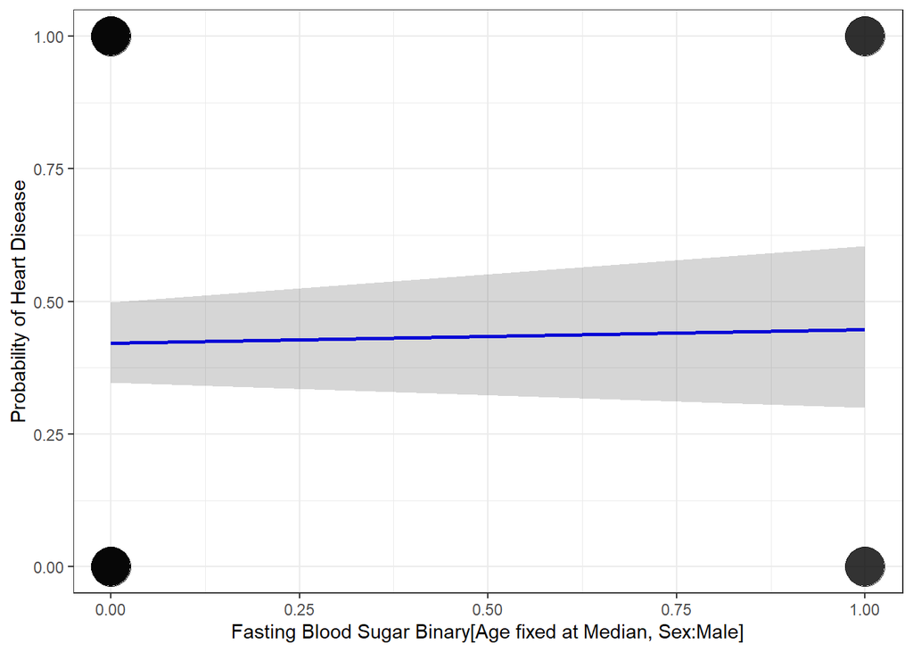

- The intercept suggests a log-odds of 4.91168 for heart disease when all predictors are zero. This is satistically significant at 0.05 level(p=5.09e-08)
- For each unit increase in fasting blood sugar (from absence to presence), the log-odds of heart disease increase by 0.10818 However, this increase is not statistically significant at the 0.05 level (p = 0.756). when age and sex are fixed.
- For each unit increase in age, the log odds of heart disease decrease by 0.06704. This decrease is statistically significant at 0.05 level(p=7.22e-06)
- For male, the log-odds of heart disease decrease by 1.54303 and is statistically significant at 0.05 level(p=1.48e-07).

### Hypothesis 1.2

**Cholestrol and Heart Disease**s

```
Call:
glm(formula = heart_disease_binary ~ cholestrol, family = binomial(link = "logit"),
    data = heart_data_new)

Coefficients:
             Estimate Std. Error z value Pr(>|z|)
(Intercept)  1.001617   0.571467   1.753   0.0797 .
cholestrol  -0.003338   0.002269  -1.471   0.1412
---
Signif. codes:  0 '***' 0.001 '**' 0.01 '*' 0.05 '.' 0.1 ' ' 1

(Dispersion parameter for binomial family taken to be 1)

    Null deviance: 417.64  on 302  degrees of freedom
Residual deviance: 415.43  on 301  degrees of freedom
AIC: 419.43

Number of Fisher Scoring iterations: 4
```

```
[1] "Adjusted R-Squared"
```

```
[1] 0.9926627
```

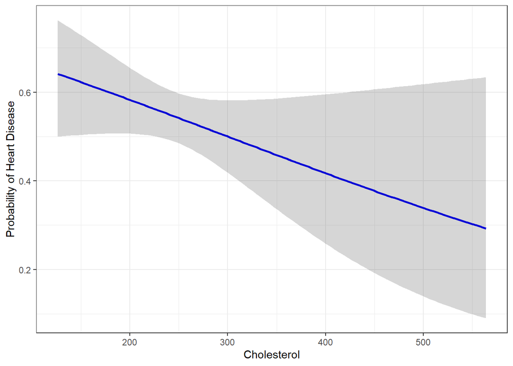

- The intercept suggests a log-odds of 1.001 for heart disease when cholestrol is zero. But this is not statistically significant at 0.05 level(p=0.07)
- For each unit increase in cholestrol level, the log-odds of heart disease decrease by 0.003338 However, this decrease is not statistically significant at the 0.05 level (p = 0.1412).

**With age and sex as control variables**

```
Call:
glm(formula = heart_disease_binary ~ cholestrol + age + sex_binary,
    family = binomial(link = "logit"), data = heart_data_new)

Coefficients:
            Estimate Std. Error z value Pr(>|z|)
(Intercept)  5.97656    1.09396   5.463 4.68e-08 ***
cholestrol  -0.00478    0.00254  -1.882   0.0598 .
age         -0.06294    0.01511  -4.164 3.12e-05 ***
sex_binary  -1.66836    0.30649  -5.444 5.22e-08 ***
---
Signif. codes:  0 '***' 0.001 '**' 0.01 '*' 0.05 '.' 0.1 ' ' 1

(Dispersion parameter for binomial family taken to be 1)

    Null deviance: 417.64  on 302  degrees of freedom
Residual deviance: 366.94  on 299  degrees of freedom
AIC: 374.94

Number of Fisher Scoring iterations: 3
```

```
[1] "Adjusted R-Squared"
```

```
[1] 0.8304528
```

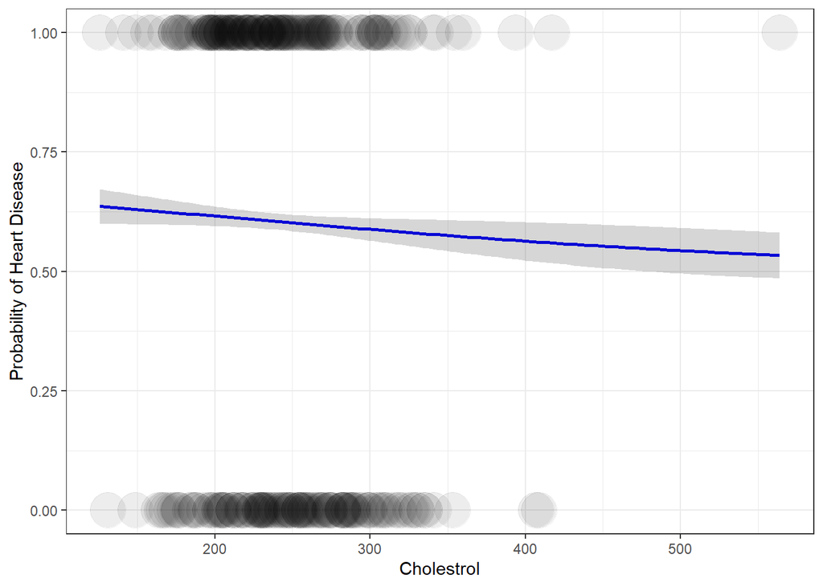

### Hypothesis 1.3

**Resting BP and Heart Disease**

```
Call:
glm(formula = heart_disease_binary ~ resting_BP, family = binomial(link = "logit"),
    data = heart_data_new)

Coefficients:
             Estimate Std. Error z value Pr(>|z|)
(Intercept)  2.409327   0.904136   2.665   0.0077 **
resting_BP  -0.016929   0.006802  -2.489   0.0128 *
---
Signif. codes:  0 '***' 0.001 '**' 0.01 '*' 0.05 '.' 0.1 ' ' 1

(Dispersion parameter for binomial family taken to be 1)

    Null deviance: 417.64  on 302  degrees of freedom
Residual deviance: 411.22  on 301  degrees of freedom
AIC: 415.22

Number of Fisher Scoring iterations: 4
```

```
[1] "Adjusted R-Squared"
```

```
[1] 0.9786937
```

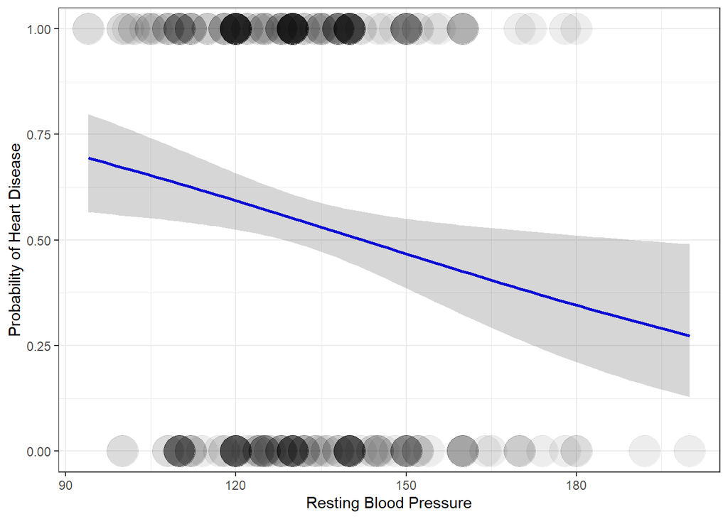

- The intercept suggests a log-odds of 2.409327 for heart disease when resting BP is zero. This is statistically significant at 0.05 level(p=0.0077)
- For each unit increase in resting_BP, the log-odds of heart disease decrease by 0.016929 and this decrease is statistically significant at 0.05 level(p=0.0128).

**With age and sex as control variables**

```
Call:
glm(formula = heart_disease_binary ~ resting_BP + age + sex_binary,
    family = binomial(link = "logit"), data = heart_data_new)

Coefficients:
             Estimate Std. Error z value Pr(>|z|)
(Intercept)  6.393482   1.241518   5.150 2.61e-07 ***
resting_BP  -0.013709   0.007512  -1.825    0.068 .
age         -0.060247   0.015232  -3.955 7.64e-05 ***
sex_binary  -1.582238   0.297454  -5.319 1.04e-07 ***
---
Signif. codes:  0 '***' 0.001 '**' 0.01 '*' 0.05 '.' 0.1 ' ' 1

(Dispersion parameter for binomial family taken to be 1)

    Null deviance: 417.64  on 302  degrees of freedom
Residual deviance: 367.19  on 299  degrees of freedom
AIC: 375.19

Number of Fisher Scoring iterations: 3
```

```
[1] "Adjusted R-Squared"
```

```
[1] 0.8312694
```

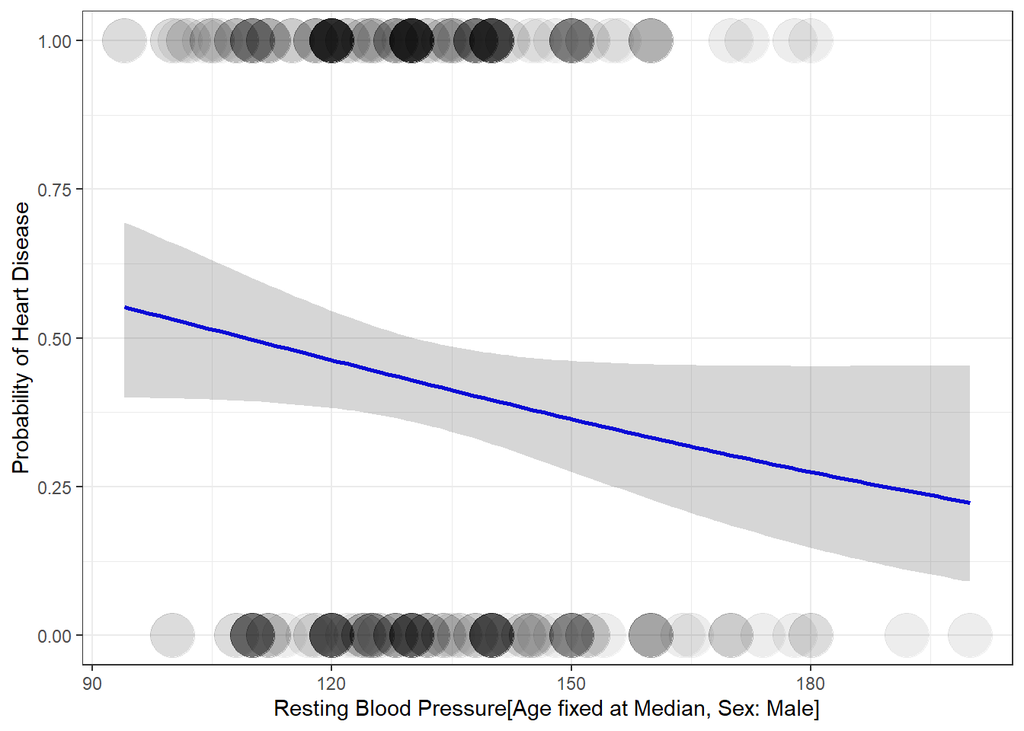

### Hypothesis 2

**Maximum Heart rate and Heart Disease**

```
Call:
glm(formula = heart_disease_binary ~ max_heart_rate, family = binomial(link = "logit"),
    data = heart_data_new)

Coefficients:
                Estimate Std. Error z value Pr(>|z|)
(Intercept)    -6.391452   0.987133  -6.475 9.50e-11 ***
max_heart_rate  0.043951   0.006531   6.729 1.71e-11 ***
---
Signif. codes:  0 '***' 0.001 '**' 0.01 '*' 0.05 '.' 0.1 ' ' 1

(Dispersion parameter for binomial family taken to be 1)

    Null deviance: 417.64  on 302  degrees of freedom
Residual deviance: 359.26  on 301  degrees of freedom
AIC: 363.26

Number of Fisher Scoring iterations: 4
```

```
[1] "Adjusted R-Squared"
```

```
[1] 0.8060427
```

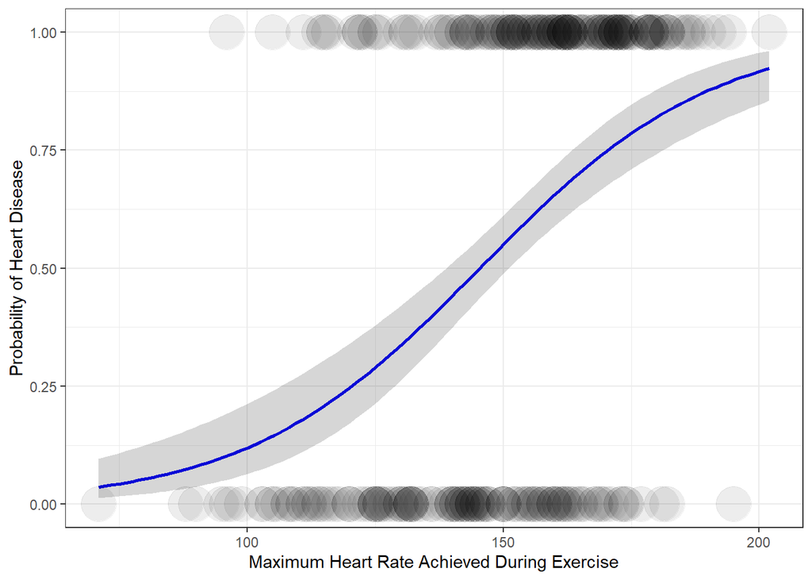

- The intercept suggests a log-odds of 6.391452 decrease in heart disease when maximum heart rate is zero. This is statistically significant at 0.05 level(p=9.50e-11)
- For each unit increase in max_heart_rate, the log-odds of heart disease increase by 0.043951 and this increase is statistically significant at 0.05 level(p=1.71e-11).

**With age and sex as control variables**

```
Call:
glm(formula = heart_disease_binary ~ max_heart_rate + age + sex_binary,
    family = binomial(link = "logit"), data = heart_data_new)

Coefficients:
                Estimate Std. Error z value Pr(>|z|)
(Intercept)    -3.187349   1.616480  -1.972   0.0486 *
max_heart_rate  0.041393   0.007135   5.802 6.57e-09 ***
age            -0.031774   0.016472  -1.929   0.0537 .
sex_binary     -1.545892   0.311924  -4.956 7.20e-07 ***
---
Signif. codes:  0 '***' 0.001 '**' 0.01 '*' 0.05 '.' 0.1 ' ' 1

(Dispersion parameter for binomial family taken to be 1)

    Null deviance: 417.64  on 302  degrees of freedom
Residual deviance: 329.91  on 299  degrees of freedom
AIC: 337.91

Number of Fisher Scoring iterations: 4
```

```
[1] "Adjusted R-Squared"
```

```
[1] 0.7065894
```

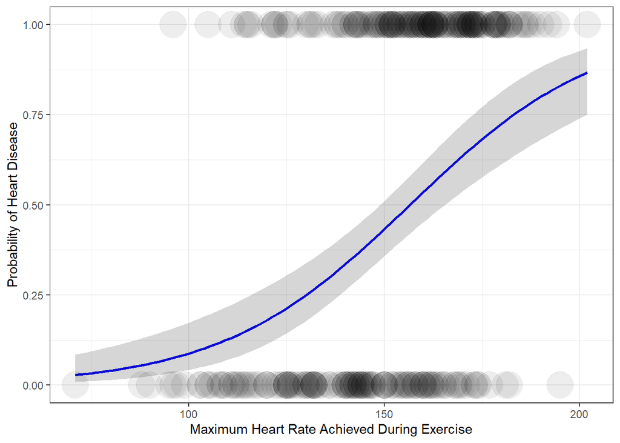

### Full Model

```
Call:
glm(formula = heart_disease_binary ~ max_heart_rate + fasting_bs_binary +
    cholestrol + resting_BP, family = binomial(link = "logit"),
    data = heart_data_new)

Coefficients:
                   Estimate Std. Error z value Pr(>|z|)
(Intercept)       -3.511718   1.438108  -2.442   0.0146 *
max_heart_rate     0.044416   0.006636   6.693 2.19e-11 ***
fasting_bs_binary -0.029925   0.364826  -0.082   0.9346
cholestrol        -0.003228   0.002437  -1.325   0.1853
resting_BP        -0.016284   0.007621  -2.137   0.0326 *
---
Signif. codes:  0 '***' 0.001 '**' 0.01 '*' 0.05 '.' 0.1 ' ' 1

(Dispersion parameter for binomial family taken to be 1)

    Null deviance: 417.64  on 302  degrees of freedom
Residual deviance: 351.86  on 298  degrees of freedom
AIC: 361.86

Number of Fisher Scoring iterations: 3
```

```
[1] "Adjusted R-Squared"
```

```
[1] 0.7792679
```

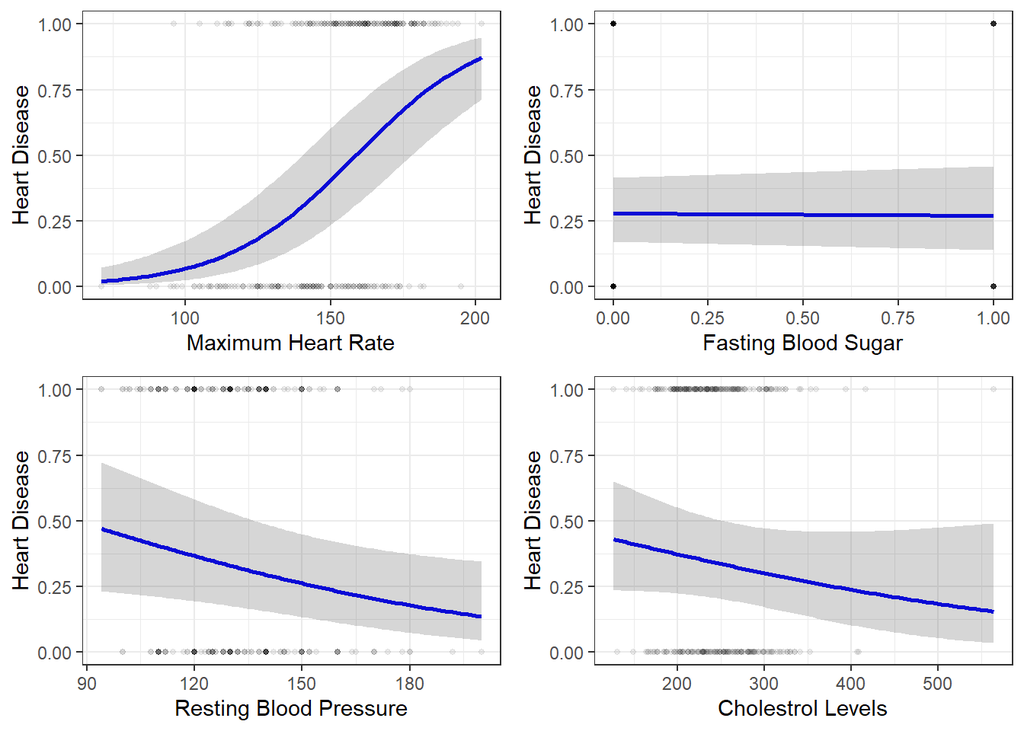

- The intercept suggests a log-odds of 3.511718 decrease in heart disease when all predictor variables are zero. This is statistically significant at 0.05 level(p=0.0146)
- For each unit increase in max_heart_rate, the log-odds of heart disease increase by 0.044416 and this increase is statistically significant at 0.05 level(p=2.19e-11).
- For each unit increase in fasting blood sugar, the log-odds of heart disease decrease by 0.029925 and this is not statistically significant at 0.05 level(p=0.9346)
- For each unit increase in cholestrol, the log-odds of heart disease decrease by 0.003228 and this is not statistically significant at 0.05 level(p=0.1853)
- For each unit increase in resting BP, the log-odds of heart disease decrease by 0.016284 and this decrease is statistically significant at 0.05 level(p=0.0326 )

**Complete model with Age & Sex as control variables**

```
Call:
glm(formula = heart_disease_binary ~ max_heart_rate + fasting_bs_binary +
    cholestrol + resting_BP + age + sex_binary, family = binomial(link = "logit"),
    data = heart_data_new)

Coefficients:
                   Estimate Std. Error z value Pr(>|z|)
(Intercept)       -0.293415   1.841907  -0.159   0.8734
max_heart_rate     0.046941   0.007705   6.092 1.12e-09 ***
fasting_bs_binary  0.107264   0.376736   0.285   0.7759
cholestrol        -0.007085   0.002764  -2.563   0.0104 *
resting_BP        -0.020430   0.008444  -2.420   0.0155 *
age               -0.014864   0.017645  -0.842   0.3996
sex_binary        -1.864455   0.343373  -5.430 5.64e-08 ***
---
Signif. codes:  0 '***' 0.001 '**' 0.01 '*' 0.05 '.' 0.1 ' ' 1

(Dispersion parameter for binomial family taken to be 1)

    Null deviance: 417.64  on 302  degrees of freedom
Residual deviance: 316.61  on 296  degrees of freedom
AIC: 330.61

Number of Fisher Scoring iterations: 4
```

```
[1] "Adjusted R-Squared"
```

```
[1] 0.658686
```

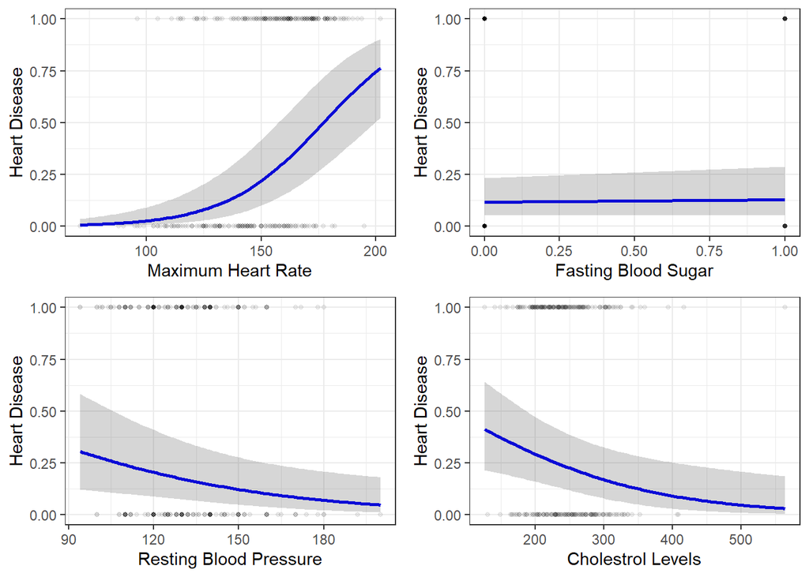

- The intercept suggests a log-odds of 0.293415 decrease in heart disease when all predictor variables are zero. This is not statistically significant at 0.05 level(p=0.8734)
- For each unit increase in max_heart_rate, the log-odds of heart disease increase by 0.046941 and this increase is statistically significant at 0.05 level(p=1.12e-09), when age and sex are fixed
- For each unit increase in fasting blood sugar, the log-odds of heart disease increase by 0.107264 and this is not statistically significant at 0.05 level(p=0.7759), when age and sex are fixed
- For each unit increase in cholestrol, the log-odds of heart disease decrease by 0.007085 and this decrease is statistically significant at 0.05 level(p=0.0104), when age and sex are fixed
- For each unit increase in resting BP, the log-odds of heart disease decrease by 0.020430 and this decrease is statistically significant at 0.05 level(p=0.0155), when age and sex are fixed
- For each unit increase in age, the log-odds of heart disease decrease by 0.014864 and this decrease is not statistically significant at 0.05 level(p=0.3996)
- For male, the log-odds of heart disease decrease by 1.864455 and this decrease is statistically significant at 0.05 level(p=5.64e-08)

## Selecting a model by comparing

We have three predictor variables for research question 1, let’s try different logistic models. Then compare AIC and Adjusted R-squared scores for each model.

Complete model including age and sex as control variables has lower AIC and Adjusted R-squared of 0.6586

```
                   df      AIC
disease_fbs         2 421.4004
disease_fbs1        4 378.4774
disease_chol        2 419.4295
disease_chol1       4 374.9434
disease_hbp         2 415.2248
disease_hbp1        4 375.1876
disease_heartRate   2 363.2569
disease_heartRate1  4 337.9083
complete_model      7 330.6091
complete_model1     5 361.8599
```

```
[1] "Adjusted R-Squared"
```

```
[1] 0.658686
```

## Stargazer Output

I’ve generated a stargazer output for complete model without control variables to compare the best-fit finalized models, which is complete model with control variables. This allows us to assess the association strength between the response variable (heart disease) and all predictors in both research questions.

```
==============================================
                      Dependent variable:
                  ----------------------------
                      heart_disease_binary
                        (1)           (2)
----------------------------------------------
max_heart_rate       0.044***       0.047***
                      (0.007)       (0.008)

fasting_bs_binary     -0.030         0.107
                      (0.365)       (0.377)

cholestrol            -0.003        -0.007**
                      (0.002)       (0.003)

resting_BP           -0.016**       -0.020**
                      (0.008)       (0.008)

age                                  -0.015
                                    (0.018)

sex_binary                         -1.864***
                                    (0.343)

Constant             -3.512**        -0.293
                      (1.438)       (1.842)

----------------------------------------------
Observations            303           303
Log Likelihood       -175.930       -158.305
Akaike Inf. Crit.     361.860       330.609
==============================================
Note:              *p<0.1; **p<0.05; ***p<0.01
```

## Diagnostics

### Complete Model

**Linearity**

**Influential Values**

**Multicollinearity**

A VIF value that exceeds 5 or 10 indicates a problematic amount of collinearity. In our case, there is no collinearity: all variables have a value of VIF well below 5.

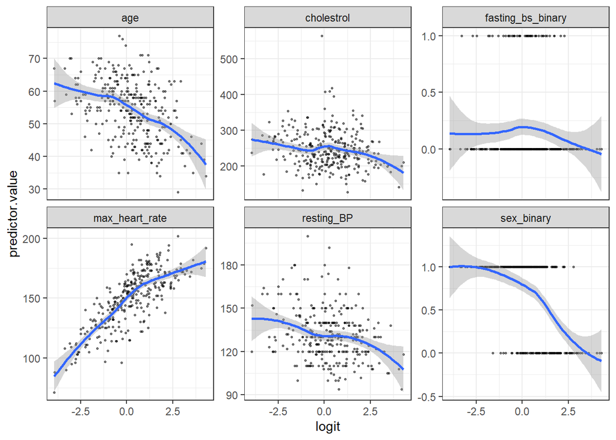

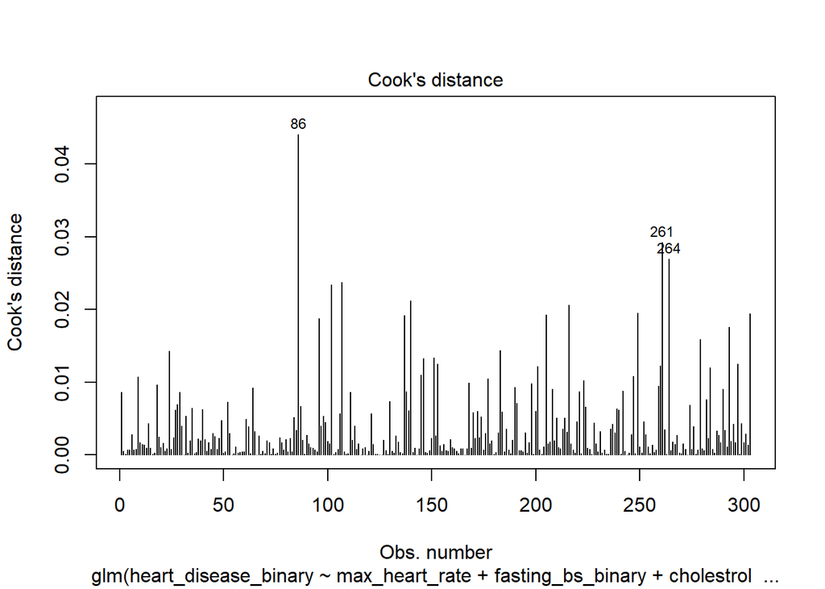

```
# A tibble: 3 × 14
  heart_disease_binary max_heart_rate fasting_bs_binary cholestrol resting_BP
                 <dbl>          <int>             <dbl>      <int>      <int>
1                    1            160                 0        564        115
2                    0            165                 1        228        178
3                    0            169                 0        269        108
# ℹ 9 more variables: age <int>, sex_binary <dbl>, .fitted <dbl>, .resid <dbl>,
#   .hat <dbl>, .sigma <dbl>, .cooksd <dbl>, .std.resid <dbl>, index <int>
```

**Plot the standarized result**

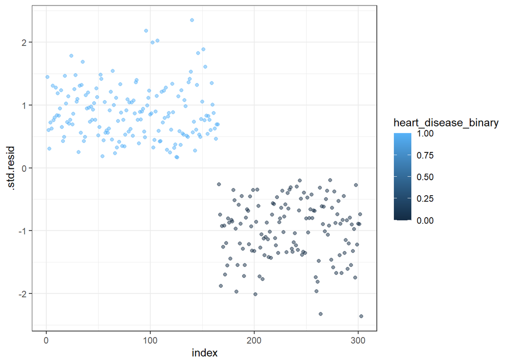

**Filter potential influential data points with abs(.std.res) > 3:**

```
# A tibble: 0 × 14
# ℹ 14 variables: heart_disease_binary <dbl>, max_heart_rate <int>,
#   fasting_bs_binary <dbl>, cholestrol <int>, resting_BP <int>, age <int>,
#   sex_binary <dbl>, .fitted <dbl>, .resid <dbl>, .hat <dbl>, .sigma <dbl>,
#   .cooksd <dbl>, .std.resid <dbl>, index <int>
```

```
   max_heart_rate fasting_bs_binary        cholestrol        resting_BP
         1.225985          1.033397          1.173649          1.140679
              age        sex_binary
         1.268442          1.233465
```

## Conclusion

In conclusion, our study sheds light on the various factors contributing to heart disease risk. We’ve identified important predictors and questioned common beliefs, emphasizing the need for thorough risk assessment methods. These findings have important implications for preventing heart disease and tailoring health strategies to individuals.

## Future Scope

Future research could delve deeper into the interplay between these predictors and explore additional variables that may contribute to heart disease risk.

## References:

- D’Agostino, R. B., Vasan, R. S., Pencina, M. J., et al. (2008). General cardiovascular risk profile for use in primary care: the Framingham Heart Study. Circulation, 117(6), 743-753.
- Lloyd-Jones, D. M., Leip, E. P., Larson, M. G., et al. (2006). Prediction of lifetime risk for cardiovascular disease by risk factor burden at 50 years of age. Circulation, 113(6), 791-798.
- Yusuf, S., Hawken, S., Ounpuu, S., et al. (2004). Effect of potentially modifiable risk factors associated with myocardial infarction in 52 countries (the INTERHEART study): case-control study. The Lancet, 364(9438), 937-952.
- Hemingway, H., & Marmot, M. (1999). Evidence-based cardiology: psychosocial factors in the aetiology and prognosis of coronary heart disease: systematic review of prospective cohort studies. BMJ, 318(7196), 1460-1467.
- Gupta, D. K., Wang, T. J., Claggett, B., et al. (2020). Association of plasma biomarkers of cardiovascular risk with maximum heart rate achieved: a population-based study. JAMA Cardiology, 5(9), 1008-1017.